# R Notebook

Load necessary data

```r
library(dplyr)
library(tidyr)
library(unmarked)
library(AICcmodavg)
library(combinat)
```

Modelling for Great Hornbill

```r
backTransform(fm, type = "state")
```

```
Backtransformed linear combination(s) of Occupancy estimate(s)
```

| Estimate | SE | LinComb | (Intercept) |
| --- | --- | --- | --- |
| 0.3317373 | 0.05194679 | -0.7003381 | 1 |

```
Transformation: logistic
```

**Now, to add some covariates. First, assuming constant detection:**

### Step 1 — Fit Global Detection Model (Ψ = null)

model selection for *p* while keeping the null model of Ψ constant

```r
summary(global_det)
```

```
Call:
occu(formula = ~experience + visit + proportion + hunting.24 +
    shifting_cultivation + evergreen_deciduous_forest + dist.to.grid +
    canopy_height + road_length + agricuture ~ 1, data = umf)

Occupancy (logit-scale):
```

|  | Estimate | SE | z | P(>\|z\|) |
| --- | --- | --- | --- | --- |
| (Intercept) | -0.2361386 | 0.2907009 | -0.8123077 | 0.4166151 |

```
Detection (logit-scale):
```

|  | Estimate | SE | z | P(>\|z\|) |
| --- | --- | --- | --- | --- |
| (Intercept) | 0.51983620 | 0.7216344 | 0.7203595 | 0.471303672 |
| experience | 0.10276670 | 0.3182540 | 0.3229078 | 0.746765087 |
| visit | 1.41708746 | 0.4725797 | 2.9986211 | 0.002712044 |
| proportion | 0.07069048 | 0.2412868 | 0.2929728 | 0.769542922 |
| hunting.24yes | -1.44912004 | 0.7594192 | -1.9081953 | 0.056365983 |
| shifting_cultivation | -1.51305551 | 0.5742040 | -2.6350485 | 0.008412526 |
| evergreen_deciduous_forest | 1.22405594 | 0.6783899 | 1.8043545 | 0.071175754 |
| dist.to.grid | 0.08697280 | 0.2594877 | 0.3351712 | 0.737495966 |
| canopy_height | -0.05609082 | 0.3884501 | -0.1443965 | 0.885187415 |
| road_length | 0.43119540 | 0.3210229 | 1.3431922 | 0.179209742 |

[output cut: 1 more lines]

```
AIC: 217.3195
Number of sites: 93
```

### Step 2 — Simplify Global Detection Model

Exclude covariates where SE >= |β|:

```r
simplified_global_det_summary <- summary(simplified_global_det)
```

```
Call:
occu(formula = ~visit + hunting.24 + shifting_cultivation + evergreen_deciduous_forest +
    road_length ~ 1, data = umf)

Occupancy (logit-scale):
```

|  | Estimate | SE | z | P(>\|z\|) |
| --- | --- | --- | --- | --- |
| (Intercept) | -0.2691834 | 0.2747609 | -0.9797008 | 0.3272338 |

```
Detection (logit-scale):
```

|  | Estimate | SE | z | P(>\|z\|) |
| --- | --- | --- | --- | --- |
| (Intercept) | 0.6200456 | 0.5855879 | 1.058843 | 0.2896712959 |
| visit | 1.4749405 | 0.4050342 | 3.641521 | 0.0002710325 |
| hunting.24yes | -1.4530096 | 0.6242123 | -2.327749 | 0.0199254326 |
| shifting_cultivation | -1.5725974 | 0.5329768 | -2.950593 | 0.0031716484 |
| evergreen_deciduous_forest | 1.1057158 | 0.5721932 | 1.932417 | 0.0533080785 |
| road_length | 0.3607862 | 0.2810091 | 1.283895 | 0.1991786696 |

```
AIC: 207.8742
Number of sites: 93
```

### Note: we found that the following are not explanatory covariates for P:

experience, proportion, dist.to.grid, canopy_height, and agriculture

meaning it does not affect the detection probability for Great Hornbill.

#### Step 3 — GOF on Simplified Global Detection Model

```r
cat("c-hat for detection:", chat_det, "\n")
```

```
c-hat for detection: 1.067564
```

This is your actual test statistic from the data.

**c-hat for detection:**

```
1.067564
```

A c-hat close to 1 means **no overdispersion**, so your QAICc and AICc values will be very similar. Your model assumptions are not violated and you can proceed

### Step 4 — Build Competing Detection Models

Using only the remaining covariates after simplification:

```r
# QAICc model selection
step1_table <- aictab(
  cand.set = det_model_list,
  modnames = names(det_model_list),
  c.hat    = chat_det  # use your c-hat from Step 8
)


# Top models within delta QAICc <= 2
cat("\nTop occupancy models (delta QAICc <= 2):\n")
```

```
Top occupancy models (delta QAICc <= 2):
```

```r
step1_table_filtered <- step1_table[step1_table$Delta_QAICc <= 2, ]
print(step1_table[step1_table$Delta_QAICc <= 2, ])
```

```
Model selection based on QAICc:
(c-hat estimate = 1.067564)

                                                                             K  QAICc
visit_hunting.24_shifting_cultivation_evergreen_deciduous_forest             7 198.57
visit_hunting.24_shifting_cultivation_evergreen_deciduous_forest_road_length 8 199.32
visit_hunting.24_shifting_cultivation                                        6 199.49
                                                                             Delta_QAICc
visit_hunting.24_shifting_cultivation_evergreen_deciduous_forest                    0.00
visit_hunting.24_shifting_cultivation_evergreen_deciduous_forest_road_length        0.75
visit_hunting.24_shifting_cultivation                                               0.93
                                                                             QAICcWt Cum.Wt
visit_hunting.24_shifting_cultivation_evergreen_deciduous_forest                0.27   0.27
visit_hunting.24_shifting_cultivation_evergreen_deciduous_forest_road_length    0.18   0.45
visit_hunting.24_shifting_cultivation                                           0.17   0.61
                                                                             Quasi.LL
visit_hunting.24_shifting_cultivation_evergreen_deciduous_forest               -91.62
visit_hunting.24_shifting_cultivation_evergreen_deciduous_forest_road_length   -90.80
visit_hunting.24_shifting_cultivation                                          -93.26
```

3 models are within ΔAICc < 2

But to be sure let us do another fitcheck with these two models, a more penalizing one.

```r
pb
```

```
Call:
parboot(object = det_model_list$visit_shifting_cultivation_area_pa, statistic = fitstats, nsim = 1000, report = TRUE, method = "nonparboot")

Parametric Bootstrap Statistics:
```

|  | t0 | mean(t0 - t_B) | StdDev(t0 - t_B) | Pr(t_B > t0) |
| --- | --- | --- | --- | --- |
| SSE | 41.25412 | 1.1282229 | 4.219267 | 0.4065934 |
| Chisq | 210.97608 | -9.5305860 | 49.129366 | 0.5324675 |
| freemanTukey | 54.00765 | 0.3774087 | 4.984326 | 0.4985015 |

```
t_B quantiles:
              0% 2.5% 25% 50% 75% 97.5% 100%
SSE           23   31  38  40  43    48   53
Chisq        135  160 196 213 235   322  754
freemanTukey  34   43  51  54  57    63   68

t0 = Original statistic computed from data
t_B = Vector of bootstrap samples
```

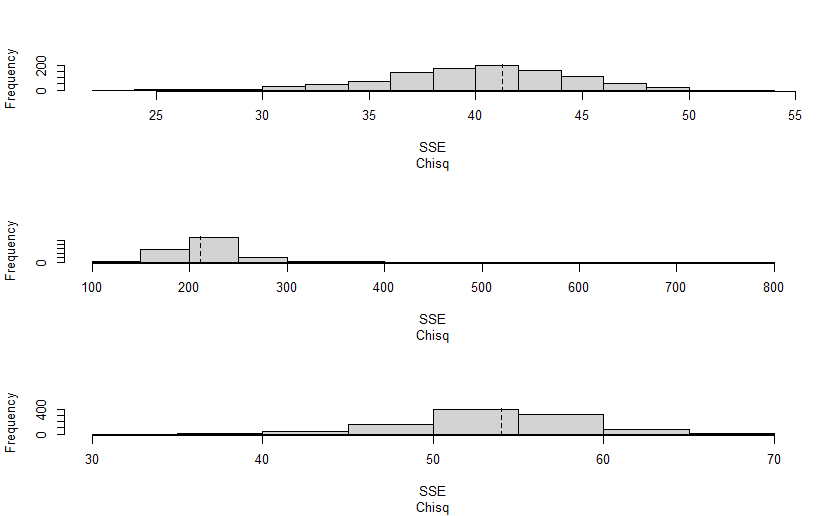

```r
par(mfrow = c(3,1))

plot(pb,
     main = "",
     xlab = c("SSE", "Chisq", "FT"))
```

**Now for the next best model - visit_hunt_shift**

```r
pb <- parboot(det_model_list$visit_hunting.24_shifting_cultivation_evergreen_deciduous_forest,
              fitstats,
              nsim = 1000,
              report = TRUE,
              method = "nonparboot")

pb
```

```
Call:
parboot(object = det_model_list$visit_hunting.24_shifting_cultivation_evergreen_deciduous_forest, statistic = fitstats, nsim = 1000, report = TRUE, method = "nonparboot")

Parametric Bootstrap Statistics:
```

|  | t0 | mean(t0 - t_B) | StdDev(t0 - t_B) | Pr(t_B > t0) |
| --- | --- | --- | --- | --- |
| SSE | 42.73932 | 1.765630 | 4.238771 | 0.3746254 |
| Chisq | 224.67199 | 11.269051 | 68.718927 | 0.2627373 |
| freemanTukey | 56.63993 | 2.482095 | 4.894362 | 0.3286713 |

```
t_B quantiles:
              0% 2.5% 25% 50% 75% 97.5% 100%
SSE           23   32  38  41  44    49   52
Chisq        116  154 184 204 226   332 1524
freemanTukey  30   44  51  54  57    63   68

t0 = Original statistic computed from data
t_B = Vector of bootstrap samples
```

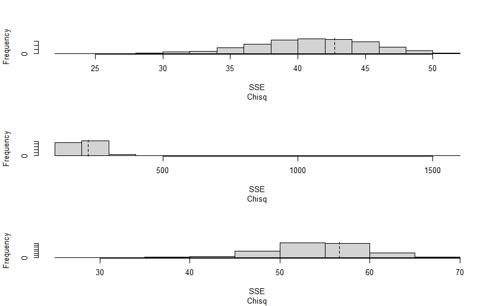

```r
par(mfrow = c(3,1))

plot(pb,
     main = "",
     xlab = c("SSE", "Chisq", "FT"))
```

Let us use **visit_hunting.24_shifting_cultivation_evergreen_deciduous_forest** model for modelling occupancy because it has a better QAICc score and weight.

### Step 6 — Fit Global Occupancy Model (fix best detection)

```r
summary(global_occ)
```

```
Call:
occu(formula = ~visit + hunting.24 + shifting_cultivation + evergreen_deciduous_forest ~
    hunting.24 + shifting_cultivation + mean_elev + road_length +
        area_pa + evergreen_deciduous_forest + canopy_height +
        aspect + agricuture + X_populationmean.x, data = umf)

Occupancy (logit-scale):
```

|  | Estimate | SE | z | P(>\|z\|) |
| --- | --- | --- | --- | --- |
| (Intercept) | -1.7445864328 | 0.7476328 | -2.3334803109 | 0.019622951 |
| hunting.24yes | 0.7094986592 | 0.7783002 | 0.9116002941 | 0.361979168 |
| shifting_cultivation | -2.4760111057 | 0.8497413 | -2.9138409301 | 0.003570118 |
| mean_elev | -0.9065496463 | 0.4193977 | -2.1615511047 | 0.030652794 |
| road_length | 0.7670032689 | 0.5071199 | 1.5124692775 | 0.130414523 |
| area_pa | 0.4186929124 | 0.3182728 | 1.3155157669 | 0.188336622 |
| evergreen_deciduous_forest | -1.3140488285 | 1.0400070 | -1.2634999262 | 0.206409573 |
| canopy_height | -0.0004591758 | 0.5790336 | -0.0007930037 | 0.999367275 |
| aspect | 0.6925081174 | 0.3610485 | 1.9180475915 | 0.055104977 |
| agricuture | -1.5699133081 | 0.8178116 | -1.9196516583 | 0.054901914 |

[output cut: 1 more lines]

```
Detection (logit-scale):
```

|  | Estimate | SE | z | P(>\|z\|) |
| --- | --- | --- | --- | --- |
| (Intercept) | 1.759639 | 0.7682688 | 2.290395 | 0.021998417 |
| visit | 1.442891 | 0.4444927 | 3.246152 | 0.001169762 |
| hunting.24yes | -1.512874 | 0.6261922 | -2.415990 | 0.015692503 |
| shifting_cultivation | 0.152489 | 0.7006803 | 0.217630 | 0.827717427 |
| evergreen_deciduous_forest | 1.213170 | 0.4110429 | 2.951443 | 0.003162929 |

```
AIC: 194.2187
Number of sites: 93
```

#### Step 7 — Simplify Global Occupancy Model

```r
# Extract occupancy coefficients and SEs
occ_coefs <- as.data.frame(summary(global_occ)$state)
```

```
Call:
occu(formula = ~visit + hunting.24 + shifting_cultivation + evergreen_deciduous_forest ~
    hunting.24 + shifting_cultivation + mean_elev + road_length +
        area_pa + evergreen_deciduous_forest + canopy_height +
        aspect + agricuture + X_populationmean.x, data = umf)

Occupancy (logit-scale):
```

|  | Estimate | SE | z | P(>\|z\|) |
| --- | --- | --- | --- | --- |
| (Intercept) | -1.7445864328 | 0.7476328 | -2.3334803109 | 0.019622951 |
| hunting.24yes | 0.7094986592 | 0.7783002 | 0.9116002941 | 0.361979168 |
| shifting_cultivation | -2.4760111057 | 0.8497413 | -2.9138409301 | 0.003570118 |
| mean_elev | -0.9065496463 | 0.4193977 | -2.1615511047 | 0.030652794 |
| road_length | 0.7670032689 | 0.5071199 | 1.5124692775 | 0.130414523 |
| area_pa | 0.4186929124 | 0.3182728 | 1.3155157669 | 0.188336622 |
| evergreen_deciduous_forest | -1.3140488285 | 1.0400070 | -1.2634999262 | 0.206409573 |
| canopy_height | -0.0004591758 | 0.5790336 | -0.0007930037 | 0.999367275 |
| aspect | 0.6925081174 | 0.3610485 | 1.9180475915 | 0.055104977 |
| agricuture | -1.5699133081 | 0.8178116 | -1.9196516583 | 0.054901914 |

[output cut: 1 more lines]

```
Detection (logit-scale):
```

|  | Estimate | SE | z | P(>\|z\|) |
| --- | --- | --- | --- | --- |
| (Intercept) | 1.759639 | 0.7682688 | 2.290395 | 0.021998417 |
| visit | 1.442891 | 0.4444927 | 3.246152 | 0.001169762 |
| hunting.24yes | -1.512874 | 0.6261922 | -2.415990 | 0.015692503 |
| shifting_cultivation | 0.152489 | 0.7006803 | 0.217630 | 0.827717427 |
| evergreen_deciduous_forest | 1.213170 | 0.4110429 | 2.951443 | 0.003162929 |

```
AIC: 194.2187
Number of sites: 93
```

Very interstingly we find that, the following have |SE| > the beta estimates:

hunting and canopy height!

indicating they do not have a significant effect on the occupancy of GH.

**Before going ahead**

#### WE note the relations of covariates on the occupancy of gh inferred by the global occupancy model

[output not shown]

| **mean_elev** | -0.9065496463 | 0.4193977 | =-0.5 |
| --- | --- | --- | --- |

| **road_length** | 0.7670032689 | 0.5071199 | =0.25 |
| --- | --- | --- | --- |

| **area_pa** | 0.4186929124 | 0.3182728 | =0.1 |
| --- | --- | --- | --- |

| **evergreen_deciduous_forest** | -1.3140488285 | 1.0400070 | =-0.3 |
| --- | --- | --- | --- |

| **aspect** | 0.6925081174 | 0.3610485 | =0.33 |
| --- | --- | --- | --- |

| **agricuture** | -1.5699133081 | 0.8178116 | =-0.7 |
| --- | --- | --- | --- |

| **X_populationmean.x** | -0.6788002701 | 0.6241253 | =0.01 |
| --- | --- | --- | --- |

**Refit simplified global:**

```r
# Example after exclusion
simplified_global_occ <- occu(~ visit + hunting.24 + shifting_cultivation
                   + evergreen_deciduous_forest
                   ~ shifting_cultivation + mean_elev
                   + road_length + area_pa + evergreen_deciduous_forest
                   + aspect + agricuture + X_populationmean.x,
                   data = umf)
```

#### Step 8 — GOF on Simplified Global Occupancy Model

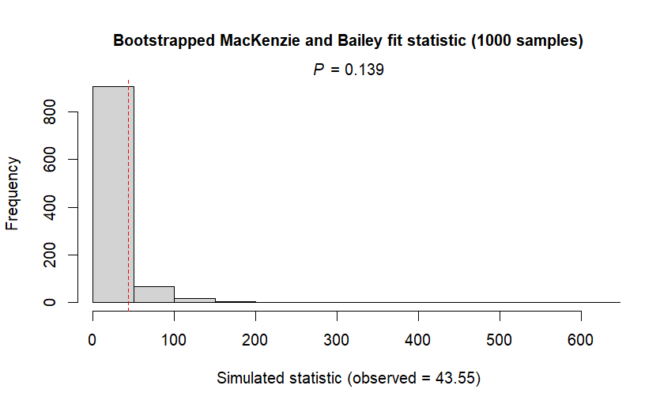

```r
gof_occ  <- mb.gof.test(simplified_global_occ, nsim = 1000, plot.hist = TRUE)
```

```r
chat_occ <- gof_occ$c.hat.est
cat("c-hat for occupancy:", chat_occ, "\n")
```

```
c-hat for occupancy: 1.340155
```

```r
#1.431156
```

[output not shown]

two options

1. go ahead with QAICc model selection by spefying c.hat in sicmodelavg function - accepted in literature
2. Use a different detection model

**Let’s try with a simpler detection model.**

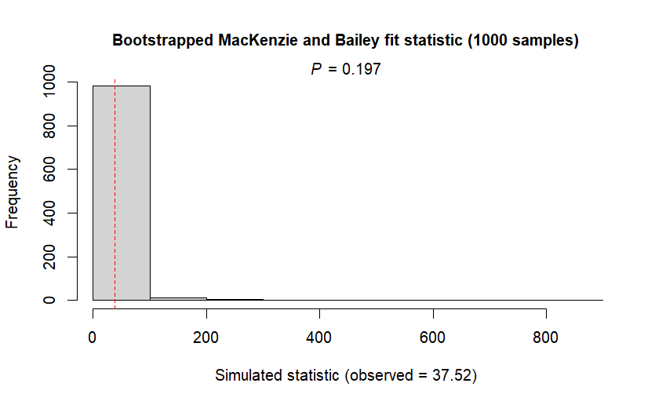

```r
simplified_global_occ <- occu(~ visit + hunting.24 + shifting_cultivation
                   ~ shifting_cultivation + mean_elev
                   + road_length
                   + aspect + agricuture,
                   data = umf)

### gof test
gof_occ  <- mb.gof.test(simplified_global_occ, nsim = 1000, plot.hist = TRUE)
chat_occ <- gof_occ$c.hat.est
cat("c-hat for occupancy:", chat_occ, "\n")
```

```
c-hat for occupancy: 1.187019
```

```r
chat_occ <- gof_occ$c.hat.est
cat("c-hat for occupancy:", chat_occ, "\n")
```

```
c-hat for occupancy: 1.187019
```

[output not shown]

c-hat is now closer to 1! however only by a margin, yet we loose on important variables like human population, area under forest. So let us use the first model only but with caution and explicitely providing c-hat whenever assessing the further models.

#### Step 9 — Build All Competing Occupancy Models

Build singular and all additive combinations of retained covariates:

```r
print(step2_table_filtered)
```

```
Model selection based on QAICc:
(c-hat estimate = 1.340155)

                                                                             K  QAICc
shifting_cultivation_mean_elev_agricuture                                   10 151.24
shifting_cultivation_mean_elev_agricuture                                   10 151.24
shifting_cultivation_mean_elev_aspect_agricuture                            11 151.71
shifting_cultivation_mean_elev_aspect_agricuture                            11 151.71
shifting_cultivation_mean_elev_road_length_aspect_agricuture                12 151.83
shifting_cultivation_mean_elev_road_length_aspect_agricuture                12 151.83
shifting_cultivation_mean_elev_road_length_agricuture                       11 152.04
shifting_cultivation_mean_elev_road_length_agricuture                       11 152.04
shifting_cultivation_mean_elev_evergreen_deciduous_forest_agricuture        11 152.37
shifting_cultivation_mean_elev_evergreen_deciduous_forest_agricuture        11 152.37
shifting_cultivation_mean_elev_X_populationmean.x                           10 152.56
shifting_cultivation_mean_elev_X_populationmean.x                           10 152.56
shifting_cultivation_mean_elev_evergreen_deciduous_forest_aspect_agricuture 12 153.24
shifting_cultivation_mean_elev_evergreen_deciduous_forest_aspect_agricuture 12 153.24
                                                                            Delta_QAICc
shifting_cultivation_mean_elev_agricuture                                          0.00
shifting_cultivation_mean_elev_agricuture                                          0.00
shifting_cultivation_mean_elev_aspect_agricuture                                   0.46
shifting_cultivation_mean_elev_aspect_agricuture                                   0.46
shifting_cultivation_mean_elev_road_length_aspect_agricuture                       0.59
shifting_cultivation_mean_elev_road_length_aspect_agricuture                       0.59
shifting_cultivation_mean_elev_road_length_agricuture                              0.80
shifting_cultivation_mean_elev_road_length_agricuture                              0.80
shifting_cultivation_mean_elev_evergreen_deciduous_forest_agricuture               1.12
shifting_cultivation_mean_elev_evergreen_deciduous_forest_agricuture               1.12
shifting_cultivation_mean_elev_X_populationmean.x                                  1.32
shifting_cultivation_mean_elev_X_populationmean.x                                  1.32
shifting_cultivation_mean_elev_evergreen_deciduous_forest_aspect_agricuture        2.00
shifting_cultivation_mean_elev_evergreen_deciduous_forest_aspect_agricuture        2.00
                                                                            QAICcWt Cum.Wt
shifting_cultivation_mean_elev_agricuture                                      0.03   0.03
shifting_cultivation_mean_elev_agricuture                                      0.03   0.05
shifting_cultivation_mean_elev_aspect_agricuture                               0.02   0.08
shifting_cultivation_mean_elev_aspect_agricuture                               0.02   0.10
shifting_cultivation_mean_elev_road_length_aspect_agricuture                   0.02   0.12
shifting_cultivation_mean_elev_road_length_aspect_agricuture                   0.02   0.14
```

[output cut: 8 more lines]

```
                                                                            Quasi.LL
shifting_cultivation_mean_elev_agricuture                                     -64.28
shifting_cultivation_mean_elev_agricuture                                     -64.28
shifting_cultivation_mean_elev_aspect_agricuture                              -63.22
shifting_cultivation_mean_elev_aspect_agricuture                              -63.22
shifting_cultivation_mean_elev_road_length_aspect_agricuture                  -61.97
shifting_cultivation_mean_elev_road_length_aspect_agricuture                  -61.97
shifting_cultivation_mean_elev_road_length_agricuture                         -63.39
shifting_cultivation_mean_elev_road_length_agricuture                         -63.39
shifting_cultivation_mean_elev_evergreen_deciduous_forest_agricuture          -63.55
shifting_cultivation_mean_elev_evergreen_deciduous_forest_agricuture          -63.55
shifting_cultivation_mean_elev_X_populationmean.x                             -64.94
shifting_cultivation_mean_elev_X_populationmean.x                             -64.94
shifting_cultivation_mean_elev_evergreen_deciduous_forest_aspect_agricuture   -62.67
shifting_cultivation_mean_elev_evergreen_deciduous_forest_aspect_agricuture   -62.67
```

#### Step 10: finding the averaged model

Now that we have the top models for occupancy let us find the average model to find the occupancy of this species

```r
model1@AIC
```

```
[1] 194.8184
```

Model 1

```r
a <-summary(selected_model)
```

```
Call:
occu(formula = formula(formula_str), data = umf)

Occupancy (logit-scale):
```

|  | Estimate | SE | z | P(>\|z\|) |
| --- | --- | --- | --- | --- |
| (Intercept) | -1.1706862 | 0.3822769 | -3.062404 | 0.002195670 |
| shifting_cultivation | -1.7871547 | 0.5901726 | -3.028190 | 0.002460233 |
| mean_elev | -0.8508519 | 0.3260599 | -2.609496 | 0.009067576 |
| aspect | 0.5008937 | 0.3148317 | 1.590989 | 0.111612129 |
| agricuture | -0.8676803 | 0.4296099 | -2.019694 | 0.043415177 |

```
Detection (logit-scale):
```

|  | Estimate | SE | z | P(>\|z\|) |
| --- | --- | --- | --- | --- |
| (Intercept) | 2.0162980 | 0.8081242 | 2.4950348 | 0.012594478 |
| visit | 1.4489780 | 0.4559717 | 3.1777804 | 0.001484071 |
| hunting.24yes | -1.6742089 | 0.6345180 | -2.6385522 | 0.008326087 |
| shifting_cultivation | 0.2829333 | 0.7159471 | 0.3951874 | 0.692704586 |
| evergreen_deciduous_forest | 0.9301850 | 0.4864799 | 1.9120730 | 0.055866834 |

```
AIC: 189.4573
Number of sites: 93
```

[output not shown]

```r
#2
top_models[[2]]
```

```
Call:
occu(formula = formula(formula_str), data = umf)

Occupancy (logit-scale):
```

|  | Estimate | SE | z | P(>\|z\|) |
| --- | --- | --- | --- | --- |
| (Intercept) | -1.1033502 | 0.3694864 | -2.986172 | 0.002824933 |
| shifting_cultivation | -1.6363940 | 0.5631973 | -2.905543 | 0.003666163 |
| mean_elev | -1.0479219 | 0.3747600 | -2.796248 | 0.005169974 |
| dist.to.grid | 0.9757133 | 0.4365939 | 2.234830 | 0.025428493 |
| aspect | 0.3957543 | 0.3127098 | 1.265564 | 0.205669172 |
| agricuture | -0.8308457 | 0.4602074 | -1.805372 | 0.071016450 |

```
Detection (logit-scale):
```

|  | Estimate | SE | z | P(>\|z\|) |
| --- | --- | --- | --- | --- |
| (Intercept) | 0.7569210 | 0.3209663 | 2.3582568 | 0.018360989 |
| experience | -0.2416943 | 0.2598206 | -0.9302351 | 0.352249348 |
| visit | 0.9408164 | 0.3575038 | 2.6316262 | 0.008497731 |
| proportion | 0.1291577 | 0.2051698 | 0.6295162 | 0.529011172 |

```
AIC: 195.0768
Number of sites: 93
```

```r
#3
top_models[[3]]
```

```
Call:
occu(formula = formula(formula_str), data = umf)

Occupancy (logit-scale):
```

|  | Estimate | SE | z | P(>\|z\|) |
| --- | --- | --- | --- | --- |
| (Intercept) | -1.0911928 | 0.3512616 | -3.106496 | 0.001893186 |
| shifting_cultivation | -1.5312458 | 0.5251604 | -2.915768 | 0.003548146 |
| mean_elev | -0.6608491 | 0.2991524 | -2.209072 | 0.027169653 |
| dist.to.grid | 1.0047557 | 0.4065819 | 2.471226 | 0.013465077 |

```
Detection (logit-scale):
```

|  | Estimate | SE | z | P(>\|z\|) |
| --- | --- | --- | --- | --- |
| (Intercept) | 0.7808543 | 0.3166942 | 2.4656413 | 0.013676823 |
| experience | -0.2463899 | 0.2606947 | -0.9451282 | 0.344593411 |
| visit | 0.9528356 | 0.3547984 | 2.6855690 | 0.007240642 |
| proportion | 0.1239736 | 0.2049410 | 0.6049232 | 0.545230012 |

```
AIC: 198.0915
Number of sites: 93
```

```r
#4
top_models[[4]]
```

```
Call:
occu(formula = formula(formula_str), data = umf)

Occupancy (logit-scale):
```

|  | Estimate | SE | z | P(>\|z\|) |
| --- | --- | --- | --- | --- |
| (Intercept) | -1.1876341 | 0.4010338 | -2.9614319 | 0.003062122 |
| shifting_cultivation | -1.9238473 | 0.6915009 | -2.7821327 | 0.005400296 |
| mean_elev | -0.9564814 | 0.3588945 | -2.6650766 | 0.007697079 |
| road_length | 0.3785049 | 0.3986710 | 0.9494167 | 0.342408741 |
| dist.to.grid | 0.8940654 | 0.4298716 | 2.0798429 | 0.037539945 |
| agricuture | -0.8810342 | 0.5052858 | -1.7436352 | 0.081222721 |

```
Detection (logit-scale):
```

|  | Estimate | SE | z | P(>\|z\|) |
| --- | --- | --- | --- | --- |
| (Intercept) | 0.7620042 | 0.3203754 | 2.3784733 | 0.017384498 |
| experience | -0.2449579 | 0.2603849 | -0.9407531 | 0.346831393 |
| visit | 0.9465649 | 0.3557321 | 2.6608926 | 0.007793382 |
| proportion | 0.1205043 | 0.2063077 | 0.5840999 | 0.559153081 |

```
AIC: 195.8223
Number of sites: 93
```

### Now average these occupancy estimates

```r
avg_uccu_gh
```

```
[1] 0.2556014
```

remember the naive was 0.3317

Greatest affectors :

distance to grid : +

shifting agriculture : -

mean elevation : -

road length : + but SE is > beta

Agriculture : -

aspect : +

in an sub-optimal model we found

area_under_pa : +

```r
# beta = 0.5935125
antilogit(0.751)
```

```
[1] 0.6793966
```